# Lab 3

### Question 6

Repeat the workflow (point creation, re-projection to ll, subsetting by polygon, and plotting) using the terra vector features

```r
library(terra)
set.seed(802)
## beaver 2 first
beaver_2terra <- beaver2 |>
  mutate(x_geo = runif(100,0,10),
         y_geo = runif(100,0,10))
beaver_2terra <- vect(beaver_2terra, geom = c('x_geo', 'y_geo'), crs = 'EPSG:26911')
str(beaver_2terra)
```

```
## S4 class 'SpatVector' [package "terra"]
```

```r
## now beaver 1
beaver_1terra <- beaver1 |>
  mutate(x_geo = runif(114, 239652, 765537),
         y_geo = runif(114, 3875802, 4653617))
beaver_1terra <- vect(beaver_1terra, geom = c('x_geo', 'y_geo'), crs = 'EPSG:26911')
str(beaver_1terra)
```

```
## S4 class 'SpatVector' [package "terra"]
```

```r
summary(beaver_1terra)
```

```
##       day             time             temp           activ
##  Min.   :346.0   Min.   :   0.0   Min.   :36.33   Min.   :0.00000
##  1st Qu.:346.0   1st Qu.: 932.5   1st Qu.:36.76   1st Qu.:0.00000
##  Median :346.0   Median :1415.0   Median :36.87   Median :0.00000
##  Mean   :346.2   Mean   :1312.0   Mean   :36.86   Mean   :0.05263
##  3rd Qu.:346.0   3rd Qu.:1887.5   3rd Qu.:36.96   3rd Qu.:0.00000
##  Max.   :347.0   Max.   :2350.0   Max.   :37.53   Max.   :1.00000
```

```r
## reading in NV counties
NV_counties_terra <- vect("NV_County_Boundaries_shp/NV_County_Boundaries.shp", crs = 'EPSG:26911')

## changing the projections
project(NV_counties_terra,'EPSG:4269')
```

```
##  class       : SpatVector
##  geometry    : polygons
##  dimensions  : 17, 9  (geometries, attributes)
##  extent      : -120.0065, -114.0405, 35.00179, 42.00025  (xmin, xmax, ymin, ymax)
##  coord. ref. : lon/lat NAD83 (EPSG:4269)
##  names       : OBJECTID COUNTYNAME COUNTYABBR COUNTYSEAT STplandNUM STplanName
##  type        :    <int>      <chr>      <chr>      <chr>      <int>      <chr>
##  values      :        1  Churchill         CH     Fallon       4651  West Zone
##                       2       Lyon         LY  Yerington       4651  West Zone
##                       3      Clark         CL  Las Vegas       4601  East Zone
##             Label SHAPE_Leng SHAPE_Area
##             <chr>      <num>      <num>
##  Churchill County  5.562e+05  1.302e+10
##       Lyon County  4.754e+05  5.242e+09
##      Clark County  7.377e+05  2.086e+10
```

```r
project(beaver_1terra, 'EPSG:4269')
```

```
##  class       : SpatVector
##  geometry    : points
##  dimensions  : 114, 4  (geometries, attributes)
##  extent      : -119.9909, -114.1176, 35.06555, 42.00342  (xmin, xmax, ymin, ymax)
##  coord. ref. : lon/lat NAD83 (EPSG:4269)
##  names       :   day  time  temp activ
##  type        : <num> <num> <num> <num>
##  values      :   346   840 36.33     0
##                  346   850 36.34     0
##                  346   900 36.35     0
```

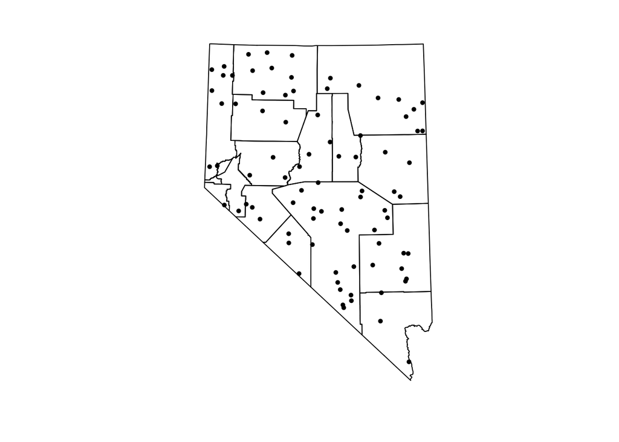

```r
terra::plot(NV_counties_terra, box = F, axes = F)
points(beaver_1terra[NV_counties_terra,])
```

### Question 7

Grad students = YES, Undergraduates = Extra Credit

Read the articles by Brewer 2006 and Yildirim and Kaya 2008 and https://source.opennews.org/articles/choosing-right-map-projection/ What are the implications of choosing an inappropriate projection for analyzing your research project?

Answer: The implications of choosing an inappropriate projection for analyzing my research project will vary depending on what my research project is. If I am mapping tree canopy change in a city or county in Ohio, I would likely want to use a UTM projection, as it is best suited to smaller areas, and even if it is not designated as an “equal area projection”, its specificity to my area of study would mean that errors in area calculations would still be limited, thus making the tree canopy change data more precise when I hand it over to policymakers. Choosing an inappropriate projection in this instance would mean that the data I hand over would have errors and thus would not result in the desired policy outcomes of improving a municipality’s green infrastructure. However, if I am working on land cover mapping over the whole United States, an equal area projection would be much more appropriate, as a UTM projection would become more distorted the further away my data got from whichever UTM zone I had chosen. If I am creating a navigation chart or a weather map, a conformal projection would be best, as it would protect from distortion of angles and preserve direction. This is important because a less appropriate direction would potentially result in my ship making a wrong turn or accidentally running onto shore as the map being used to navigate would not properly represent which direction the ship was heading in. In the case of the weather map, it would be important for a typical resident of an area to confidently understand whether a storm or other dangerous weather is present in their region and which direction it is heading in. An inappropriate projection might result in residents making unsafe choices that put themselves and others in harm’s way due to a miscommunication in where dangerous weather was headed.